# Regression Trees

Niclas Frederic Sturm

22-10-2019

## Introduction

Dieses Dokument enthält die Programmierbefehle zur Erstellung von Modellen auf Basis von Entscheidungsbäumen. Die Grundlage für die hier verwendeten Modelle sind einfache Entscheidungsbäume. Darauf aufbauend werden die »Ensemble-Lerner« erstellt. Zu diesen zählen solche Modelle, die mithilfe von »Bootstrap Aggregation« *parallel* trainiert wurden bzw. mithilfe von »Boosting« eine *tiefe* Struktur aufweisen. Die Anwendungsbeispiele in diesem Dokument beschränken sich auf Regressionsbäume, d.h. solche Bäume, deren Zielvariable stetig ist. Hierzu wurde der »UCI Crime and Communities«-Datensatz verwendet.

```r
library(rpart) # Import der notwendigen Installationen
library(rpart.plot)
library(rsample)
library(dplyr)
library(readr)
library(naniar)
library(Metrics)
library(ipred)
library(purrr)
library(ranger)
library(gbm)
library(ggplot2)
library(doParallel)
library(foreach)
library(tidyr)
library(stringr)
library(caret)

set.seed(1997) # Zur Gewährleistung von Replizierbarkeit wird im Hintergrund ein Zufallswert gesetzt
setwd("/Users/nfsturm/Documents/STATLEARN/forestranger")

crime_data <- read_csv("crimedata.csv", col_names = TRUE)
drop_cols <- c("communityname", "state", "countyCode", "communityCode", "fold", "murdPerPop", "rapesPerPop", "robbbPerPop", "assaultPerPop", "burglPerPop", "larcPerPop", "autoTheftPerPop", "arsonsPerPop", "nonViolPerPop", "murders", "rapes", "robberies", "assaults", "burglaries", "larcenies", "autoTheft", "arsons")
crime_data <- crime_data %>%
  select(-drop_cols) %>%
  replace_with_na_all(condition = ~.x == "?")

drop_vars <- miss_var_summary(crime_data)
drop_vars <- drop_vars %>%
  filter(pct_miss > 10) %>%
  select(variable) %>%
  pull()

crime_data <- crime_data %>%
  select(-drop_vars)

crime_data <- drop_na(crime_data)
crime_data <- map_at(crime_data, .at = 1:103, .f = as.numeric)
crime_data <- as_tibble(crime_data)
```

Die Modellierungsstrategie folgt einem *Split-Train-Test*-Paradigma.

```r
crime_splits <- initial_split(crime_data)
train <- training(crime_splits)
test <- testing(crime_splits)
```

Ein einfacher Regressionsbaum wird nun über »recursive partitioning« erstellt. Dieser Begriff bedeutet zunächst, dass ein Datensatz mit *p* erklärenden Variablen binär aufgeteilt wird, d.h. eine Variable wird herangezogen, um ein Trennungskriterium festzulegen. Im vorliegenden Beispiel ist die abhängige Variable »ViolentCrimesPerPop«, die eine Darstellung für die Zahl von Gewaltverbrechen pro 100,000 Einwohner ist.

## Decision Trees

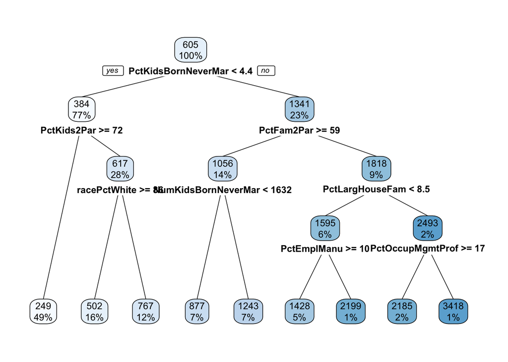

```r
tree_crime <- rpart(ViolentCrimesPerPop~., method = "anova", data = train, control = rpart.control(xval = 10))
rpart.plot(tree_crime, branch = 0.04, tweak = 1.2)
```

Der Regressionsbaum erzeugt neun unterschiedliche Vorhersagen. Wir können nun betrachten, wie die Wahl des Komplexitätsparameters $\alpha$ den relativen Fehler ($1-R^2$) beeinflusst.

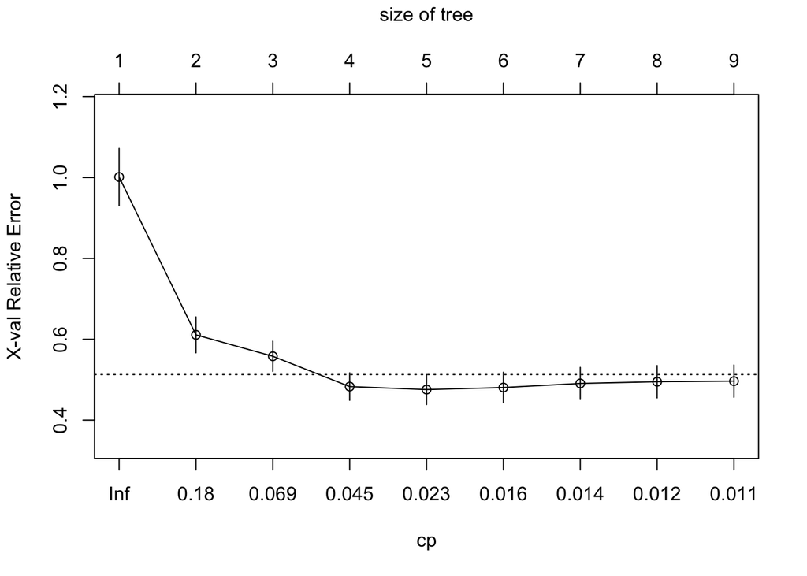

```r
plotcp(tree_crime)
```

## Bootstrap aggregating

Die »Bootstrap«-Aggregation ist ein paralleler Prozess, der sich gut nachvollziehen lässt. Die Vorgehensweise besteht darin, zunächst aus dem Training-Datensatz *k*-mal *n* Werte mit Wiederholung zu ziehen und für jeden der *k* »neuen« Datensätze einen Entscheidungsbaum zu erstellen.

```r
nr_cores <- detectCores() - 2
cl <- makeCluster(nr_cores) # Use the number of cores available minus 2
registerDoParallel(cl) # Activate parallel backend

# Fit trees in parallel and compute predictions on the test set
predictions <- foreach(
  icount(200),
  .packages = "rpart",
  .combine = cbind
   ) %dopar% {
    # Create bootstrapped copy of the training set
    index <- sample(nrow(train), replace = TRUE)
    train_boot <- train[index, ]

    # Grow tree on top of bootstrapped copy
    bagged_tree <- rpart(
      ViolentCrimesPerPop ~ .,
      control = rpart.control(minsplit = 2, cp = 0.05),
      data = train_boot
      )

    predict(bagged_tree, newdata = test)
   }
# stopCluster(cl)

predictions <- as_tibble(predictions)

predictions_df <- predictions %>%
  mutate(instance = 1:n(), actual = test$ViolentCrimesPerPop)

predictions_df2 <- gather(predictions_df, nr_tree, predicted, -c(instance, actual)) %>%
  mutate(nr_tree = str_extract(nr_tree, '\\d+'))

predictions_df2$nr_tree <- as.numeric(predictions_df2$nr_tree)

tree_prep <- predictions_df2 %>%
  arrange(instance, nr_tree) %>%
  group_by(instance) %>%
  mutate(avg_prediction = cummean(predicted)) %>%
  group_by(nr_tree) %>%
  summarize(RMSE = rmse(actual, avg_prediction))
```

Die Evaluation der Anzahl der verwendeten Bäume lässt sich gut grafisch veranschaulichen.

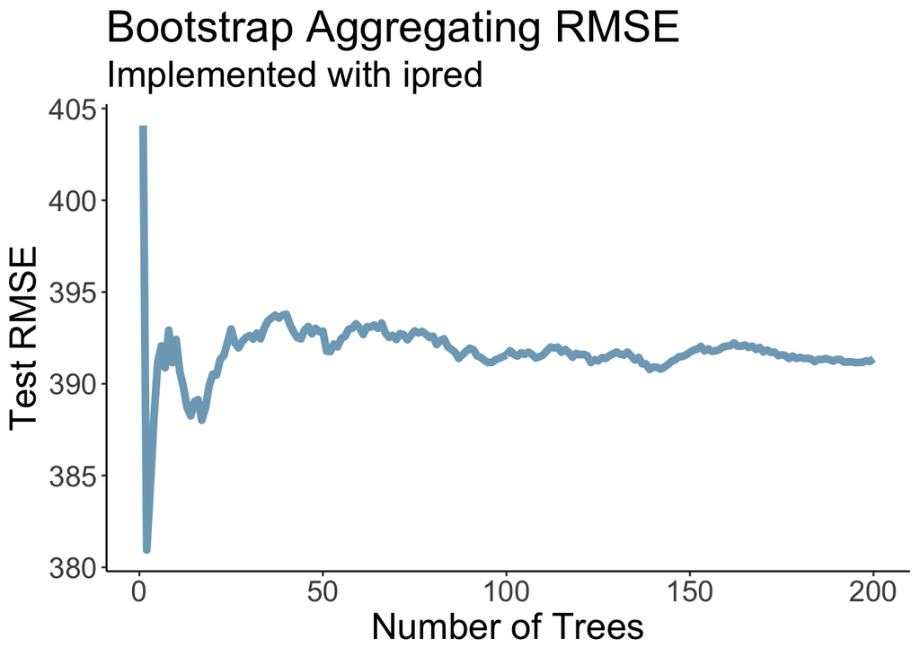

```r
ggplot(tree_prep, aes(nr_tree, RMSE)) + geom_line(col = "#7fa9c1", size = 2) + theme_classic() + theme(text = element_text(size=20)) + labs(title = "Bootstrap Aggregating RMSE", subtitle = "Implemented with ipred") + xlab("Number of Trees") + ylab("Test RMSE")
```

## Boosting

Next, a gradient boosting machine will be used. We will the popular “gbm” package to build a model.

```r
boost_model <- gbm(ViolentCrimesPerPop~., distribution = "gaussian", data = train, n.trees = 2000, shrinkage = 0.1, cv.folds = 10)
best <- which.min(boost_model$cv.error)
sqrt(boost_model$cv.error[best])
```

```
## [1] 388.1402
```

Das beste Modell erreicht einen RMSE-Wert von etwa 388.

## Random Forests

```r
cv_split <- vfold_cv(train, v = 10)

cv_data <- cv_split %>%
  mutate(train = map(splits, ~training(.x)),
         validation = map(splits, ~testing(.x)))

cv_tune <- cv_data %>%
  crossing(mtry = 1:15) %>%
  mutate(model = map2(train, mtry, .f = ~ranger(formula = ViolentCrimesPerPop~.,
  data = .x, mtry = .y)))

cv_tune <- cv_tune %>%
  mutate(validation_actual = map(validation, ~.x$ViolentCrimesPerPop)) %>%
  mutate(validation_predicted = map2(model, validation, ~predict(.x, .y)$predictions)) %>%
  mutate(validation_rmse = map2_dbl(validation_actual, validation_predicted,
                                    ~rmse(actual = .x, predicted =.y)))

cv_select <- cv_tune %>%
  select(mtry, model, validation_rmse) %>%
  group_by(mtry) %>%
  summarize(mean.rmse = mean(validation_rmse))

cv_select
```

```
## # A tibble: 15 x 2
##     mtry mean.rmse
##    <int>     <dbl>
##  1     1      400.
##  2     2      386.
##  3     3      380.
##  4     4      378.
##  5     5      375.
##  6     6      376.
##  7     7      375.
##  8     8      376.
##  9     9      377.
## 10    10      375.
## 11    11      376.
## 12    12      376.
## 13    13      375.
## 14    14      378.
## 15    15      377.
```

```r
ranger_model <- ranger(ViolentCrimesPerPop~., data = train, mtry = 5)
actual <- test$ViolentCrimesPerPop
predicted <- predict(ranger_model, test)
predicted <- predicted$predictions
rmse(actual, predicted)
```

```
## [1] 335.9218
```

We will now plot mtry against the cross-validated RMSE metric.

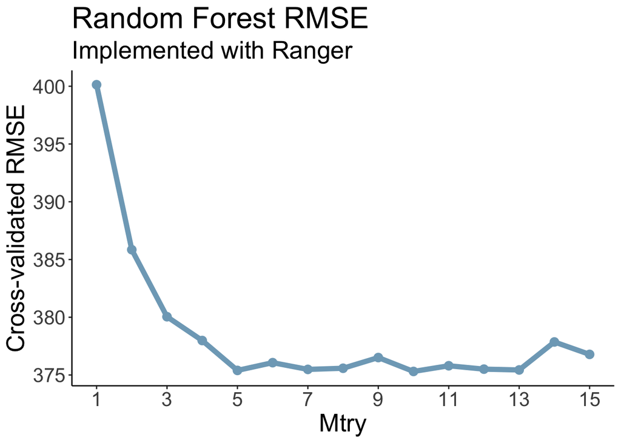

```r
ggplot(cv_select, aes(x = mtry, y = mean.rmse)) + geom_line(col = "#7fa9c1", size = 2) + geom_point(col = "#7fa9c1", size = 3) + theme_classic() + theme(text = element_text(size=20)) + labs(title = "Random Forest RMSE", subtitle = "Implemented with Ranger") + xlab("Mtry") + ylab("Cross-validated RMSE") + scale_x_continuous(breaks = seq(1, 15, 2))
```